# Relación entre la Tuberculosis y el presupuesto invertido para su prevención y control entre el 2012 y el 2018 en el Perú

26 de mayo de 2019

[figure not shown]

# Segunda Entrega

## Integrantes:

- Renzo Solórzano
- Juan Luis Barraza
- **Nathaly Dongo (Líder)**
- Del Piero Flores
- Alex Casilla

### Profesor:

#### Gálvez Perez, Humberto Emiliano

### Sección:

#### 5

## Problemática:

La inefectividad de su ejecución presupuestal nos hace preguntarnos ¿cuál es la lógica del presupuesto para la TBC en el Perú?, ¿a qué se deben estos bajos niveles de inversión efectiva?, y más importante aún ¿Cuál es la magnitud de las consecuencias que acarrea dicha inefectividad? Esta investigación pretende entender y responder a la problemática a través de un análisis estadístico de la gestión presupuestaria para la inversión de prevención y tratamiento del TBC por parte del estado en las distintas regiones y departamentos entre los años del 2012 y el 2018.

### Objetivos:

#### Objetivo General:

- Estudiar la correlación entre el presupuesto invertido para el control y la prevención de la tuberculosis y la situación epidemiológica de la TBC en el Perú entre el 2012 y 2018

#### Objetivos Específicos:

- - Comprobar la relación entre presupuesto invertido por el Ministerio de Salud y los casos de TBC en el Perú
  - Identificar la sala situacional de TBC (proporciones y tendencias) en los distintos departamentos y regiones del Perú
  - Comprobar si el presupuesto invertido por el Ministerio de Salud es el suficiente para abarcar la mayoría de los casos de TBC en el Perú

  *-**Sala situacional:** Descripción de la situación mediante la tasa de incidencia, mortalidad, morbilidad, etc.*

### Población Objetivo:

Personas que presentan casos de TBC en Perú

### Muestra:

Datos recolectados de la página oficial del Minsa.

## Preguntas planteadas

| N° | Preguntas | Tipo |
| --- | --- | --- |
| 1 | En qué años se dieron mayores casos nuevos de tuberculosis a nivel nacional | Descriptiva |
| 2 | ¿Qué departamento tuvo el presupuesto más bajo y cuál el más alto para el control y la prevención de TBC entre el 2012 y el 2018? | Descriptiva |
| 3 | ¿Cuál es el incremento de la tasa de mortalidad, debido a la TBC, entre el 2012 y 2018? | Descriptiva |
| 4 | ¿Cuáles son las zonas donde se es más propenso a contraer TBC? | Descriptiva |
| 5 | ¿Qué años tuvieron las tres tasas de mortalidad e incidencia por TBC más bajas a nivel nacional? | Descriptiva |
| 6 | ¿Existe una tendencia entre el presupuesto invertido y la tasa de mortalidad por TBC? | Exploratoria |
| 7 | ¿Los departamentos con menor presupuesto presentan una mayor o una menor cantidad de casos de TBC? | Exploratoria |
| 8 | ¿Cómo se relaciona el presupuesto invertido para la prevención con el número de casos nuevos de TBC? | Exploratoria |
| 9 | ¿La presencia de CO2 guarda alguna relación con la aparición de nuevos casos de TBC? | Inferencial |
| 10 | ¿El aumento de presupuesto se comporta de manera eficaz para la prevención y tratamiento del TBC? | Inferencial |
| 11 | ¿Es posible predecir si las personas mejorarán su estado con TBC en base al aumento del presupuesto? | Predictiva |
| 12 | ¿Es posible predecir la región a partir de la tasa de mortalidad o morbilidad por TBC? | Predictiva |
| 13 | ¿Qué factores influyen en la distribución del presupuesto para la prevención en las regiones? | Causal |
| 14 | ¿Qué factores afectan la tasa de mortalidad de TBC? | Causal |
| 15 | ¿De qué manera ciertas condiciones determinan la variación de mortalidad e incidencia de TBC? | Mecanística |
| 16 | ¿Cómo ciertas condiciones indican la distribución de presupuesto para el TBC? | Mecanística |

## Variables a estudiar

| N° | Variables | Relación con preguntas | Tipo | Subtipo de variables |
| --- | --- | --- | --- | --- |
| 1 | Año | 1,5 | Cuantitativa | Discreta |
| 2 | Departamentos | 2,7 | Cualitativa | Nominal |
| 3 | Tasa de Mortalidad | 3,14,15 | Cuantitativa | Continua |
| 4 | Región | 4,12,13 | Cualitativa | Nominal |
| 5 | Tasa de incidencia | 5 | Cuantitativa | Continua |
| 6 | Presupuesto invertido | 6,7,8,10,11,13,16 | Cuantitativa | Discreta |
| 7 | Número de casos de TBC | 1 | Cuantitativa | Discreta |
| 8 | Número de casos nuevos | 8 | Cuantitativa | Discreta |
| 9 | Presencia de CO2(miles de ton) | 9 | Cuantitativa | Continua |
| 10 | Tasa de morbilidad | 12 | Cuantitativa | Continua |
| 11 | Tasa de éxito | 10 | Cuantitativa | Continua |

## Diagrama de Gantt

Suponiendo que hay una intervalo de 3 semanas para cada entrega planificamos el siguiente Diagrama de Gantt.

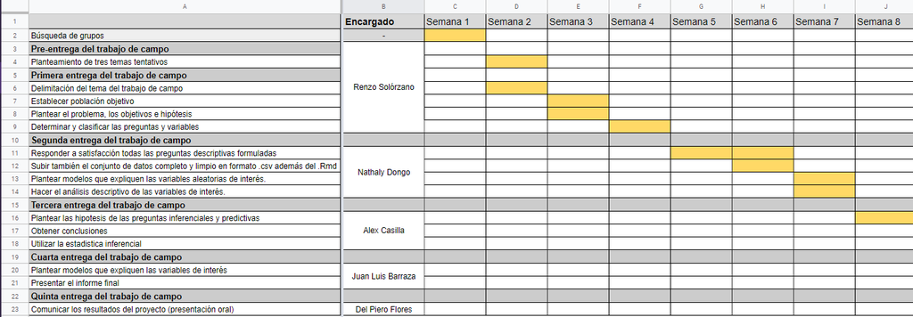

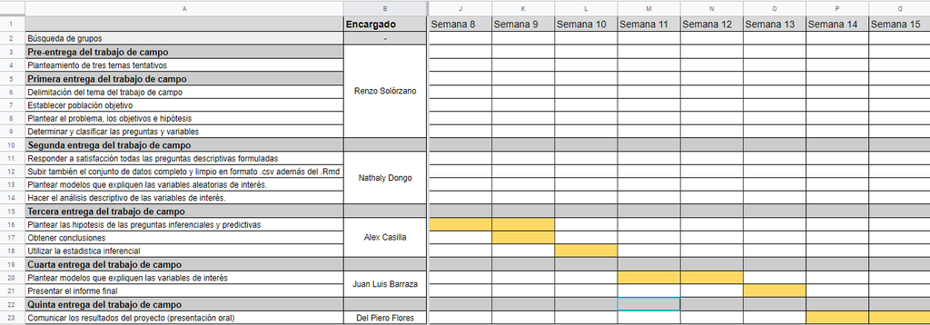

## Preguntas

### Preguntas descriptivas

**- ¿En qué años se dieron mayores casos nuevos de tuberculosis a nivel nacional?**

Para responder esta pregunta se realizó un grafico de barras de los años vs el N° de casos de TBC desde el 2012 hasta el 2018, aquí podemos identificar en que años se dieron mayores casos nuevos de tuberculosis a nivel nacional.

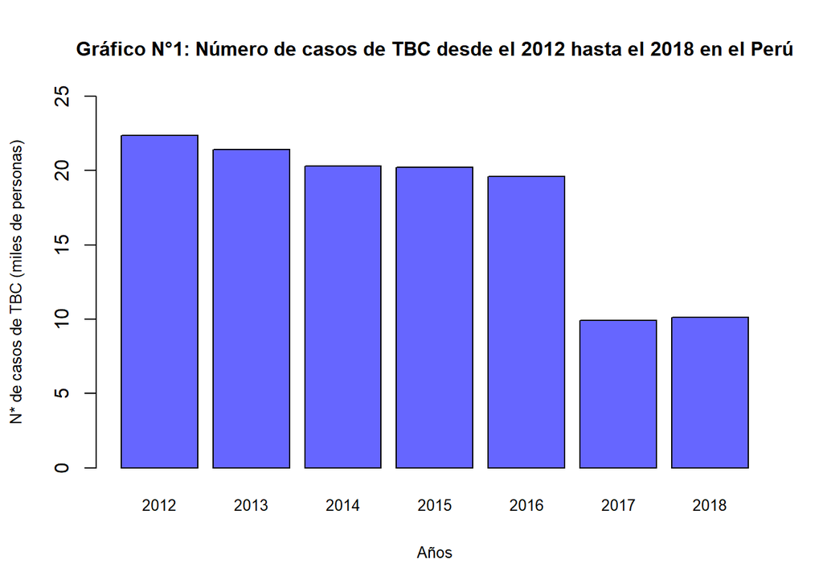

```r
x<-0
morbilidad_porr_anho<-c()
anhos<-c()
for (i in 2012:2018){
       x<-x+1
       morbilidad_porr_anho[x]<-sum(datos$Numero.de.casos.Nuevos[datos$Año==i])
       anhos[x]<-i
}
casos <- morbilidad_porr_anho/1000
names(casos)<-anhos
barplot(casos,main="Gráfico N°1: Número de casos de TBC desde el 2012 hasta el 2018 en el Perú"
        ,ylab ="N* de casos de TBC (miles de personas)"
        ,xlab ="Años"
        ,ylim=c(0,25)
        ,cex.main=1.25
        ,cex.lab=0.8
        ,col = "#6666FF"
        ,cex.main=1
        ,cex.names = 0.8)
```

Según el Gráfico N°1: Número de casos de TBC desde el 2012 hasta el 2018 en el Perú, es posible afirmar que el año **2012** fue el año en el que aparecieron un mayor número de casos nuevos de TBC a nivel nacional, aproximadamente **22.346** miles de personas. Esta cifra continuó disminuyendo en los siguiente años, sobretodo en el año **2017**. Sin embargo, es importante observar que el número de casos nuevos de TBC tuvo un ligero incremento entre el **2017** y el **2018**.

**- Qué departamento tuvo el presupuesto más bajo y cuál el más alto para el control y la prevención de TBC entre el 2012 y el 2018?**

Para determinar el presupuesto mas bajo y alto en el periodo a analizar se utilizarán la media con respecto a la distribución anual

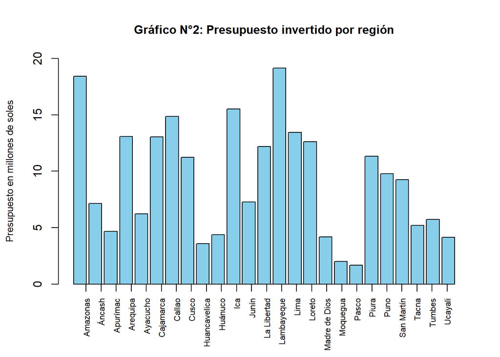

```r
departamentos1<-unique(datos$Departamento)
Departamentos<-datos$Departamento
Morbilidad<-datos$Morbilidad
Presupuesto.orientado<-datos$Presupuesto.para.el.programa.orientado.a.disminuir.la.incidencia.de.TBC.y.VIH
datos4<-data.frame(Departamentos,Morbilidad,Presupuesto.orientado)

Morbilidad2<-c()
Presupuesto.orientado2<-c()
for (i in 1:25){
aux<-sum(datos4$Morbilidad[which(datos4$Departamentos==Departamentos[c(i)])])/7
Morbilidad2<-c(Morbilidad2,aux)
aux2<-sum(datos4$Presupuesto.orientado[which(datos4$Departamentos==Departamentos[c(i)])])/7
Presupuesto.orientado2<-c(Presupuesto.orientado2,aux2)
}

P<-Presupuesto.orientado2/1000000

Departamentos2<-Departamentos[c(1,2,3,4,5,6,7,8,9,10,11,12,13,14,15,16,17,18,19,20,21,22,23,24,25)]
datos5<-data.frame(Departamentos2,Morbilidad2,Presupuesto.orientado2)
barplot(P,main="Gráfico N°2: Presupuesto invertido por región"
        ,ylab = "Presupuesto en millones de soles"
        ,width = 0.85
        ,col = "skyblue"
        ,ylim =c(0,20)
        ,cex.main=1
        ,cex.lab=0.8)
axis(1,at=1:25,labels = departamentos1,las=3,cex.axis=0.7)
```

**- ¿Cuál es el incremento de la tasa de mortalidad, debido a la TBC, entre el 2012 y 2018?**

```r
tasa12 <- datos$Tasa.de.mortalidad[which(datos$Año==2012)]
tasa13 <- datos$Tasa.de.mortalidad[which(datos$Año==2013)]
tasa14 <- datos$Tasa.de.mortalidad[which(datos$Año==2014)]
tasa15 <- datos$Tasa.de.mortalidad[which(datos$Año==2015)]
tasa16 <- datos$Tasa.de.mortalidad[which(datos$Año==2016)]
tasa17 <- datos$Tasa.de.mortalidad[which(datos$Año==2017)]
tasa18 <- datos$Tasa.de.mortalidad[which(datos$Año==2018)]
Vs=(seq(from=mean(tasa12),to=mean(tasa18),by=(mean(tasa18)-mean(tasa12))/6))
length(Vs)
```

```
## [1] 7
```

```r
length(2012:2018)
```

```
## [1] 7
```

```r
tasasprom <- c(mean(tasa12),mean(tasa13),mean(tasa14),mean(tasa15),mean(tasa16),mean(tasa17),mean(tasa18))
length(tasasprom)
```

```
## [1] 7
```

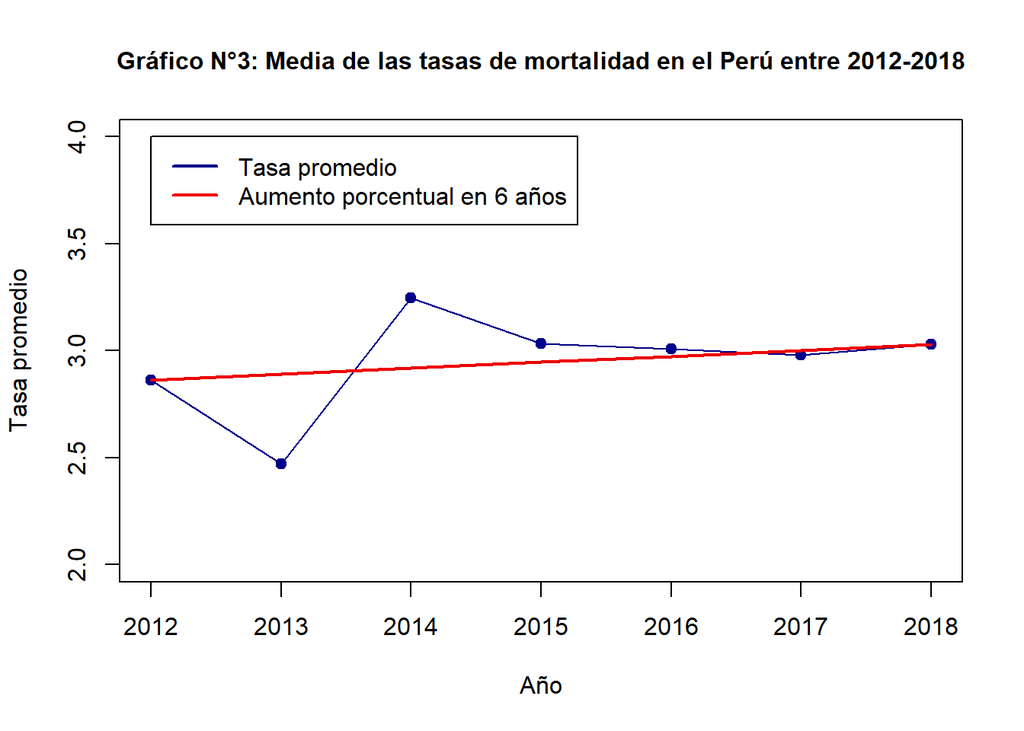

```r
plot(y=tasasprom,x = 2012:2018
     ,main = "Gráfico N°3: Media de las tasas de mortalidad en el Perú entre 2012-2018"
     ,xlab = "Año"
     ,ylab = "Tasa promedio"
     ,ylim = c(2,4)
     ,type ="o"
     ,pch = 19
     ,cex.main=1
     ,col = c("blue4"));
lines(y=Vs,x = 2012:2018, col="red2",lwd=2)
legend(2012,4,legend=c("Tasa promedio","Aumento porcentual en 6 años"),col=c("blue4","red2"),lwd=2)
```

En el Gráfico N°3 se puede observar la tasa promedio de mortalidad por TBC en el Perú. En 2012 comenzó con una tasa promedio de **2.864**, al año siguiente la tasa bajo hasta **2.472** la cual es la tasa más baja en nuestro estudio. En el 2014 se presentó la tasa más alta de mortalidad, la cual fue **3.248**. En los años siguiente se mantuvo una tasa constante de **3.012**.

Encontramos la variación porcentual entre el 2012 y 2018 `(mean(tasa18)-mean(tasa12))/mean(tasa12)*100` y lo dividimos entre 6 y obtenemos **0.95%**; aproximadamente la tasa de mortalidad promedio en Perú **ha aumentado 1%** por año.

**- ¿Cuáles son las zonas donde se es más propenso a contraer TBC?** **- ¿Qué años tuvieron las tres tasas de mortalidad e incidencia por TBC más bajas a nivel nacional?**

[figure not shown]

```r
z<-0
mortalidad<-c()
años<-c()
for(i in 2012:2018){
  z<-z+1
  mortalidad[z]<- sum(datos$Tasa.de.mortalidad[datos$Año==i])
  años[z]<-i
}
cases<-mortalidad/1000
names(cases)<-años
barplot(casos,main="Gráfico N°4: Tasa de mortalidad desde el 2012 hasta el 2018 en el Perú"
        ,ylab ="Tasa de mortalidad"
        ,xlab ="Años"
        ,ylim=c(0,30)
        ,cex.main=1
        ,cex.lab=0.8
        ,col = "#1234F8")
```

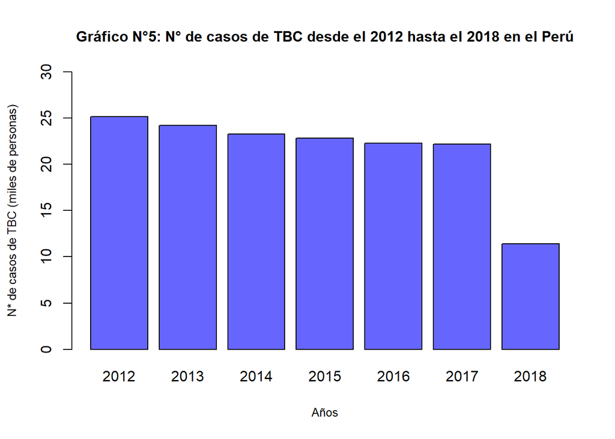

```r
x<-0
morbilidad_porr_anho<-c()
anhos<-c()
for (i in 2012:2018){
       x<-x+1
       morbilidad_porr_anho[x]<-sum(datos$Morbilidad[datos$Año==i])
       anhos[x]<-i
}
casos <- morbilidad_porr_anho/1000
names(casos)<-anhos

barplot(casos
        ,main="Gráfico N°5: N° de casos de TBC desde el 2012 hasta el 2018 en el Perú"
        ,ylab ="N* de casos de TBC (miles de personas)"
        ,xlab ="Años"
        ,ylim=c(0,30)
        ,cex.main=1
        ,cex.lab=0.8
        ,col = "#6666FF")
```

### Preguntas exploratorias

**- ¿Existe una tendencia entre el presupuesto invertido y la tasa de mortalidad por TBC?**

Para hallar la relación entre el presupuesto invertido y la tasa de mortalidad por TBC se realizó un diagrama de dispersión sobre los datos de prespuesto invertido (en millones de soles) vs la tasa de mortalidad anual por cada departamento. Así mismo, se calculó el coeficiente de correlación para discutir porsteriormente la relación entre ambas variables.

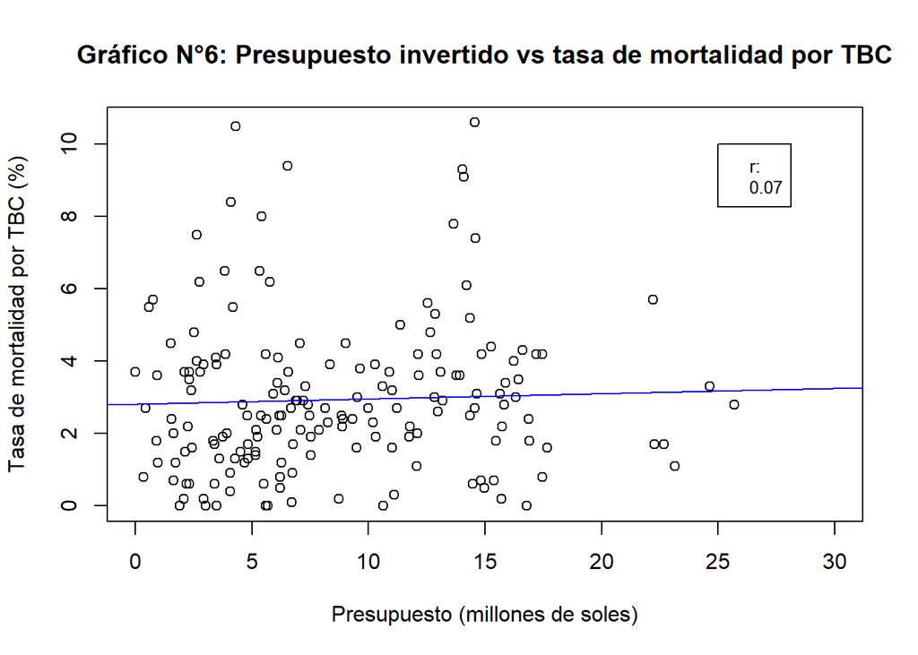

```r
Presupuesto_millones<-datos$Presupuesto.para.el.programa.orientado.a.disminuir.la.incidencia.de.TBC.y.VIH/1000000
tasa_mortalidad<-datos$Tasa.de.mortalidad
plot(Presupuesto_millones,tasa_mortalidad
     ,main="Gráfico N°6: Presupuesto invertido vs tasa de mortalidad por TBC"
     ,ylab="Tasa de mortalidad por TBC (%)"
     ,xlab="Presupuesto (millones de soles)"
     ,xlim=c(0,30))
abline(lm(tasa_mortalidad~Presupuesto_millones), col="blue")
coeficiente_es<-c("r:",round(cor(Presupuesto_millones, tasa_mortalidad),2))
legend(25, 10,legend=c(coeficiente_es),cex=0.8)
```

Según el Gráfico N°6 podemos observar que no existe una correlación entre el presupuesto invertido y la tasa de mortalidad a nivel nacional. El coeficiente de correlación es 6.624%, y el aceptado para poder establecer alguna correlación debe ser mayor a 95%. De este modo, no exist algún patrón o tendencia entre el presupuesto invertido y la tasa de mortalidad.

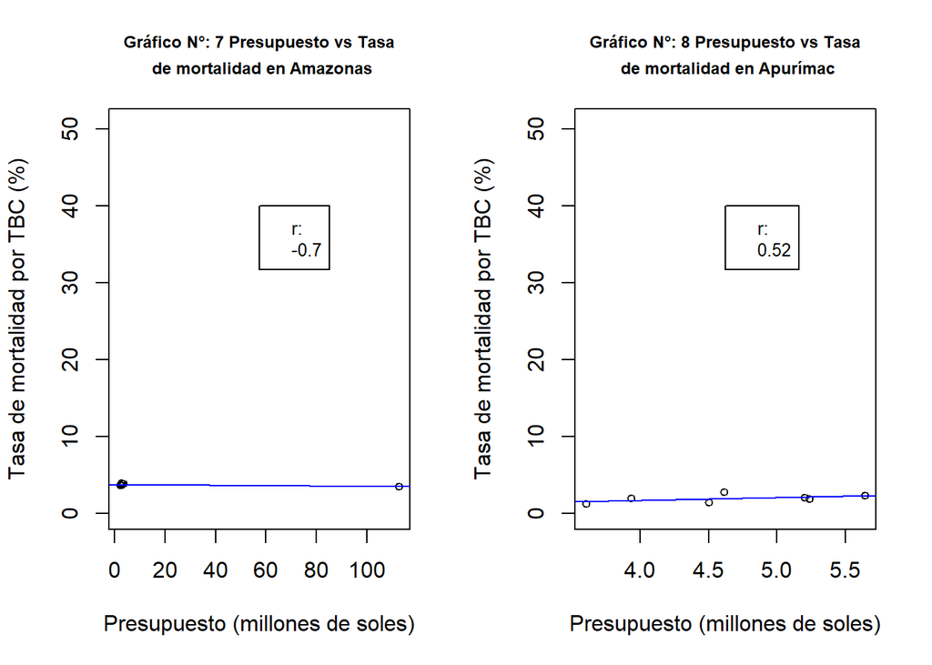

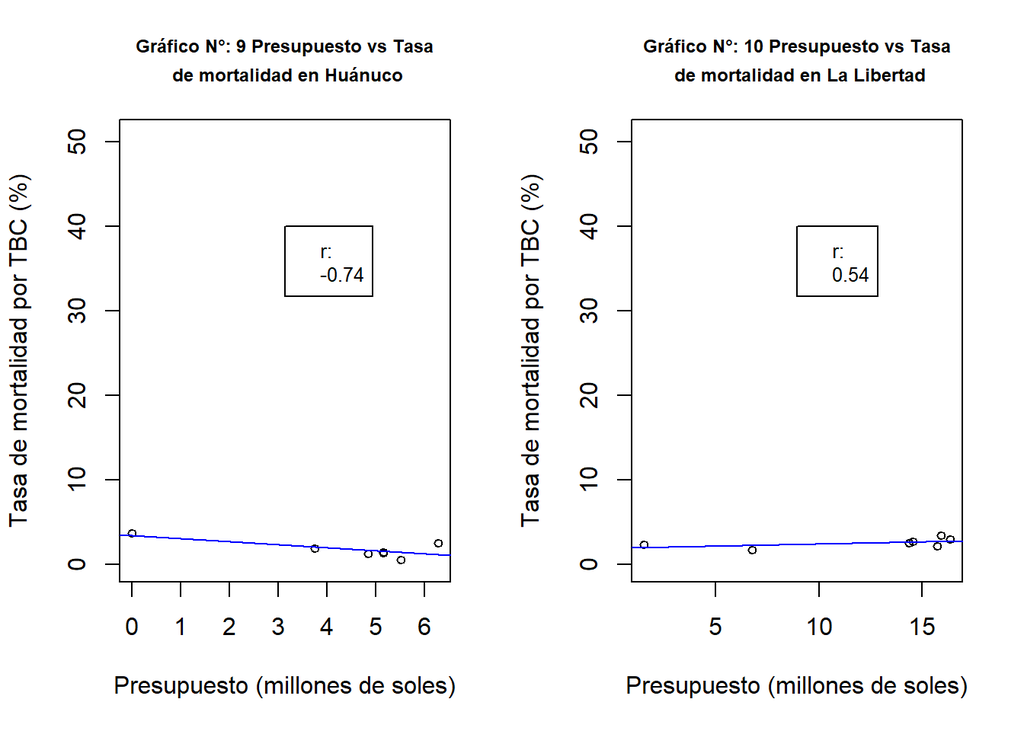

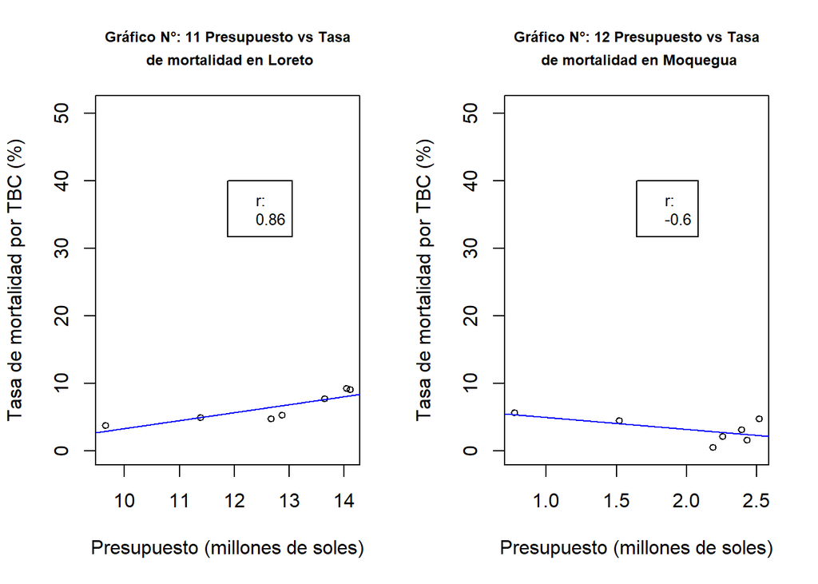

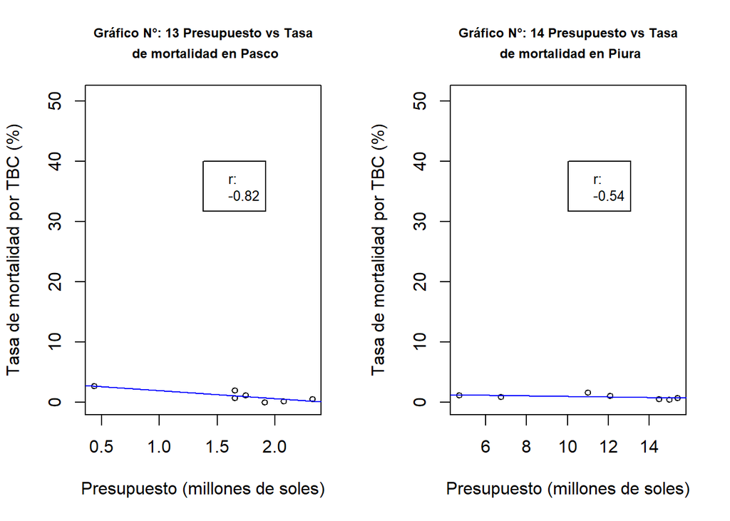

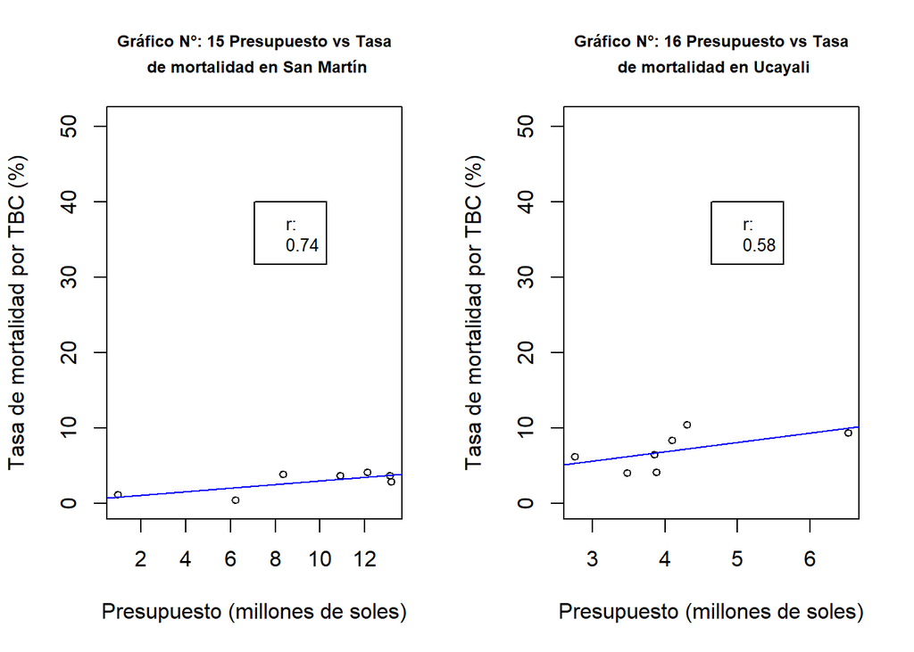

```r
departamentos<-c(names(table(datos$Departamento)))
par(mfrow=c(1,2))
x<-6
for (i in 1:length(departamentos)){
Presupuesto_millones<-datos$Presupuesto.para.el.programa.orientado.a.disminuir.la.incidencia.de.TBC.y.VIH[datos$Departamento==departamentos[i]]/1000000
tasa_mortalidad<-datos$Tasa.de.mortalidad[datos$Departamento==departamentos[i]]
cor(Presupuesto_millones, tasa_mortalidad)
coeficiente<-round(cor(Presupuesto_millones, tasa_mortalidad),2)
if(abs(coeficiente)>=0.5){
x<-x+1
nombre_depa<-c(paste("Gráfico N°:",toString(x),"Presupuesto vs Tasa",sep = " "),paste(" de mortalidad en\t", toString(departamentos[i]),sep = " "))
plot(Presupuesto_millones
     ,tasa_mortalidad,ylab="Tasa de mortalidad por TBC (%)"
     ,xlab="Presupuesto (millones de soles)"
     ,ylim = c(0,max(datos$Tasa.de.mortalidad)+40)
     ,main=nombre_depa
     ,cex.main=0.75
     ,cex= 0.75)
abline(lm(tasa_mortalidad~Presupuesto_millones), col="blue")
coeficiente_es<-c("r:",coeficiente)
legend((max(Presupuesto_millones)+min(Presupuesto_millones))/2,  40,legend=c(coeficiente_es),cex=0.8)
}}
```

**-¿Los departamentos con menor presupuesto presentan una mayor o una menor cantidad de casos de TBC?**

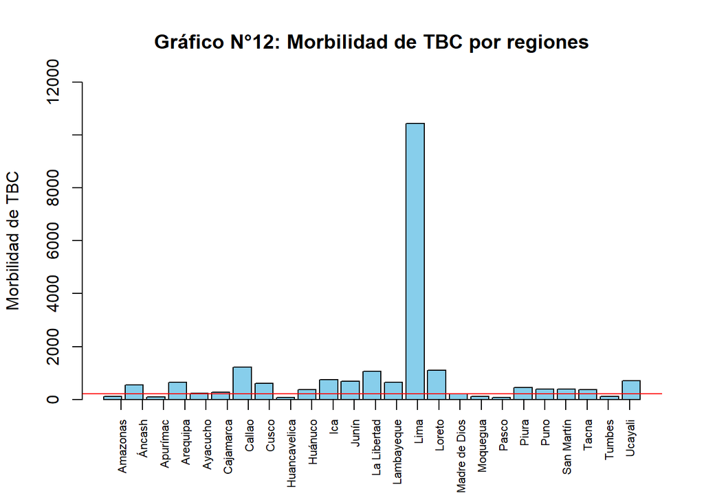

```r
Departamentos<-datos$Departamento
Morbilidad<-datos$Morbilidad
Presupuesto.orientado<-datos$Presupuesto.para.el.programa.orientado.a.disminuir.la.incidencia.de.TBC.y.VIH
datos4<-data.frame(Departamentos,Morbilidad,Presupuesto.orientado)
Morbilidad2<-c()
Presupuesto.orientado2<-c()
for (i in 1:25)
{
aux<-sum(datos4$Morbilidad[which(datos4$Departamentos==Departamentos[c(i)])])/7
Morbilidad2<-c(Morbilidad2,aux)
aux2<-sum(datos4$Presupuesto.orientado[which(datos4$Departamentos==Departamentos[c(i)])])/7
Presupuesto.orientado2<-c(Presupuesto.orientado2,aux2)
}
P<-Presupuesto.orientado2/1000000
Departamentos2<-Departamentos[c(1,2,3,4,5,6,7,8,9,10,11,12,13,14,15,16,17,18,19,20,21,22,23,24,25)]
barplot(Morbilidad2,main="Gráfico N°12: Morbilidad de TBC por regiones"
        ,ylab = "Morbilidad de TBC"
        ,width = 0.85
        ,col = "skyblue"
        ,ylim =c(0,12000))
axis(1,at=1:25,labels = departamentos1,las=3,cex.axis=0.7)
abline(h=201,col="red",lwd=1)
```

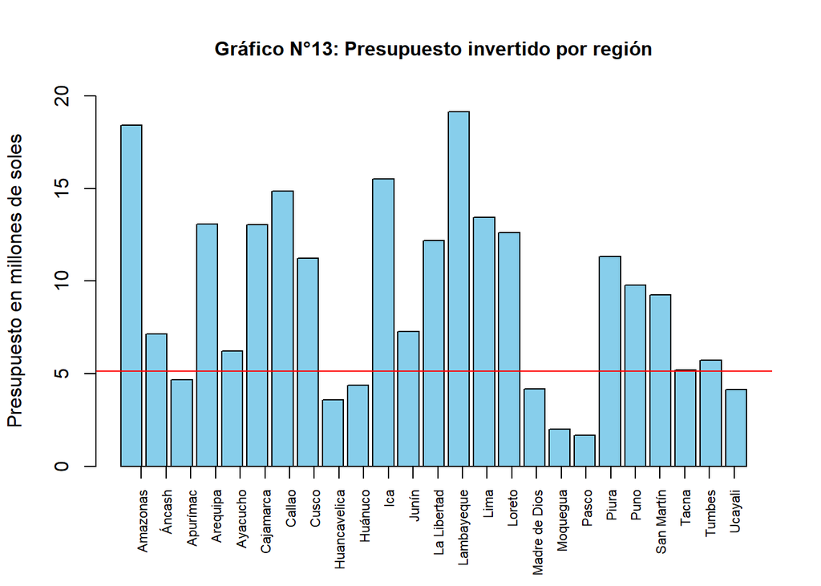

```r
barplot(P,main="Gráfico N°13: Presupuesto invertido por región"
        ,ylab = "Presupuesto en millones de soles"
        ,width = 0.85
        ,col = "skyblue"
        ,ylim =c(0,20)
        ,cex.main=1)
axis(1,at=1:25,labels = departamentos1,las=3,cex.axis=0.7)
abline(h=5.125517,col="red",lwd=1)
```

```r
q1<-quantile(P)
q2<-quantile(Morbilidad2)
```

```r
dato6<-datos5$Departamentos2[which(datos5$Presupuesto.orientado2<=5125517)]
morb3<-datos5$Morbilidad2[which(datos5$Presupuesto.orientado2<=5125517)]
```

A la vez, se determinó que las regiones con media de presupuesto inferior al primer cuartil corresponde a los departamentos de **Apurímac , Huancavelica , Huánuco , Madre de Dios, Moquegua , Pasco , Ucayali**

Esta última observación puede ser verificada por el Gráfico N°14, observando los datos de morbilidad correspondientes a estos departamentos.

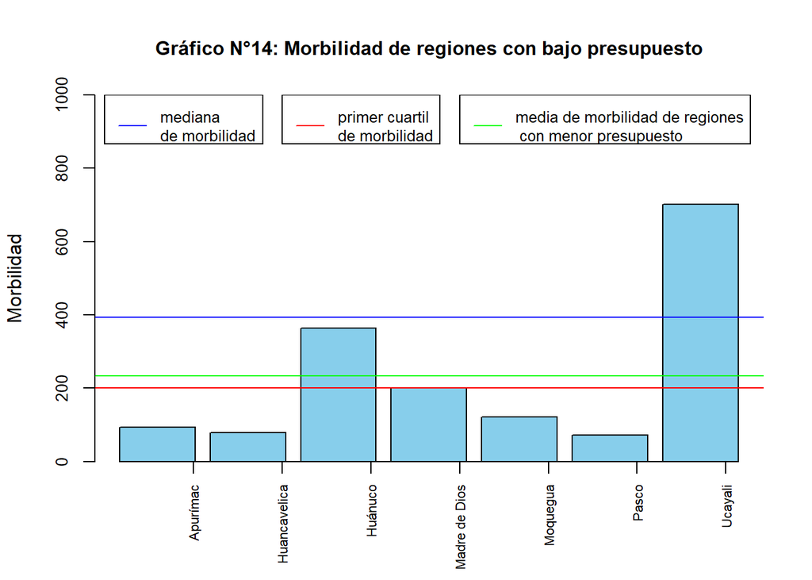

```r
barplot(morb3,main="Gráfico N°14: Morbilidad de regiones con bajo presupuesto"
        ,ylab = "Morbilidad"
        ,width = 0.85
        ,col = "skyblue"
        ,ylim =c(0,1000)
        ,cex.axis = 0.85
        ,cex.names = 0.8
        ,cex.main=1)
axis(1,at=1:7,labels = dato6,las=3,cex.axis=0.7)
abline(h=median(Morbilidad2),col="blue",lwd=1)
abline(h=201,col="red",lwd=1)
abline(h=mean(morb3),col="green",lwd=1)
legend(0,1000,legend=c("mediana\nde morbilidad"),col=c("blue"),lwd=1,cex=0.8)
legend(2,1000,legend=c("primer cuartil\nde morbilidad"),col=c("red"),lwd=1,cex=0.8)
legend(4,1000,legend=c("media de morbilidad de regiones\n con menor presupuesto"),col=c("green"),lwd=1,cex=0.8)
```

En este caso tambié se hace guía de la mendiana y el primer cuartil de los datos de morbilidad.

De las 7 regiones que presentan un menor presupuesto invertido por región, se identifica que 5 de ellos se presentan también por debajo de primer cuartil y solo la región de Ucayali supera la mediana de los datos de morbilidad, permitiendo afirmar que los departamento con menor presupuesto son los que menor cantidad de casos de TBC presentan.

**- ¿Cómo se relaciona el presupuesto invertido para la prevención con el número de casos nuevos de TBC?**

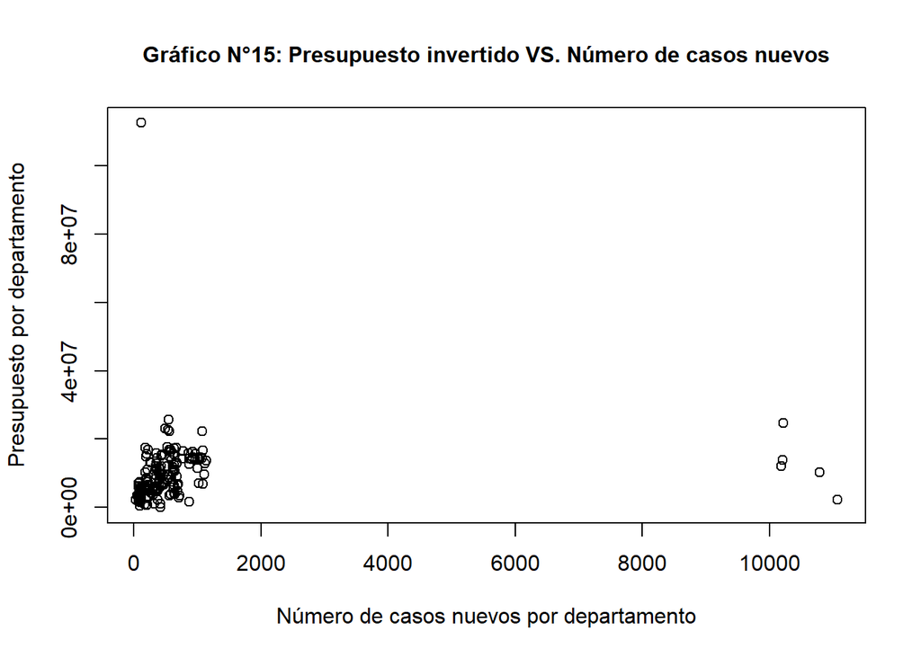

```r
plot(x=datos$Numero.de.casos.Nuevos,y=datos$Presupuesto.para.el.programa.orientado.a.disminuir.la.incidencia.de.TBC.y.VIH
     ,xlab = "Número de casos nuevos por departamento"
     ,ylab = "Presupuesto por departamento"
     ,main = "Gráfico N°15: Presupuesto invertido VS. Número de casos nuevos"
     ,cex.main=1)
```

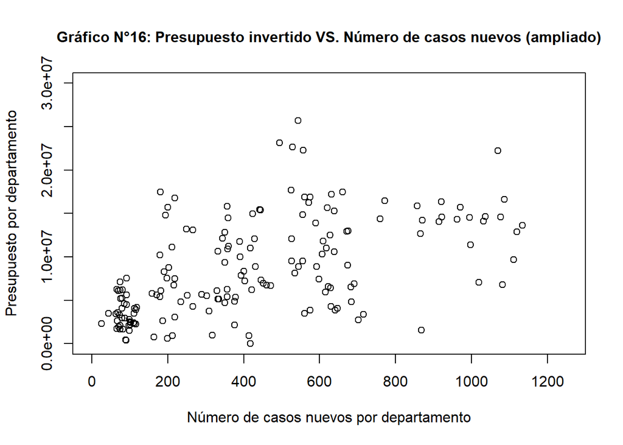

```r
plot(x = datos$Numero.de.casos.Nuevos,y = datos$Presupuesto.para.el.programa.orientado.a.disminuir.la.incidencia.de.TBC.y.VIH
     ,ylim = c(0,3*10^7),xlim=c(0,1250)
     ,xlab = "Número de casos nuevos por departamento"
     ,ylab = "Presupuesto por departamento"
     ,main = "Gráfico N°16: Presupuesto invertido VS. Número de casos nuevos (ampliado)"
     ,cex.main=1)
```

Como se puede observar en el Gráfico N°15 la mayoría de los datos se encuentran en una área muy pequeña, mientras que hay 6 datos atípicos en los extremos. Por lo tanto descartamos estos datos atípicos y disminuimos el rango en el eje “X” y “Y” para obtener el segundo gráfico.

En el Gráfico N°16 se puede encontrar un pequeño conjunto de valores en la esquina inferior izquierda. Esta relación nos indica que hay una tendencia que a menor número de casos nuevos por departamento, menor será el presupuesto invertido para aquel departamento. Sin embargo también se pueden observar departamentos en los que se tienen altos número de casos nuevos pero tienen menor presupuesto que comparado con otros con menor número de casos nuevos.

Con esta hipótesis sobre la tendencia entre los dos valores podemos darnos cuenta que en los valores atípicos se encuentran departamentos con un gran número de casos nuevos de TBC pero con el mismo presupuesto invertido que el de valores menores.

### Preguntas inferenciales

**- ¿La presencia de CO2 guarda alguna relación con la aparición de nuevos casos de TBC?**

### Preguntas predictivas

**-¿Es posible predecir si las personas mejorarán su estado con TBC en base al aumento del presupuesto?**

**-¿Es posible predecir la región a partir de la tasa de mortalidad o morbilidad por TBC?**

### Preguntas causales

**-¿Qué factores influyen en la distribución del presupuesto para la prevención en las regiones?**

**-¿Qué factores afectan la tasa de mortalidad de TBC?**

### Preguntas mecanísticas

**-¿De qué manera ciertas condiciones determinan la variación de mortalidad e incidencia de TBC?**

**-¿Cómo ciertas condiciones indican la distribución de presupuesto para el TBC?**

## Bibliografía

Alarcón, V., Alarcón, E., Figueroa, C. & Mendoza-Ticona, A. (2017). Tuberculosis en el Perú: situación epidemiológica, avances y desafíos para su control. Revista Peruana de Medicina Experimental y Salud Publica, 34(2), 299-310. Recuperado 19 abril, 2019, de https://dx.doi.org/10.17843/rpmesp.2017.342.2384

Ministerio de Salud (2017). Situación de Tuberculosis en el Perú y la respuesta del Estado (Plan de Intervención, Plan de Acción). Recuperado 19 abril, 2019 de http://www.tuberculosis.minsa.gob.pe/portaldpctb/recursos/20180605122521.pdf

Ministerio de Salud (2018). Dashboard del Departamento de Prevención y Control de Tuberculosis. Recuperado 19 abril, 2019 de http://www.tuberculosis.minsa.gob.pe/DashboardDPCTB/Dashboard.aspx#

Organización Mundial de la Salud (2018, 19 septiembre). Tuberculosis. Recuperado 19 abril, 2019, de https://www.who.int/es/news-room/fact-sheets/detail/tuberculosis

Vargas, J. (2011). Equidad e inversión en salud pública en la República. Revista Cubana de Salud Pública , 452-461 . Recuperado 19 abril, 2019 de http://scielo.sld.cu/pdf/rcsp/v37n4/spu09411.pdf